# **JAWABAN UTS-REGRESSION MODEL**

Nama: Ameliatus Sholichah NIM: A3202300024 Matkul: Regression Model Institut Teknologi Statistika dan Bisnis Muhammadiyah Semarang

2025-05-06

**SOAL NO 1:**  
Mari Kita Selesaikan Masalah Sarah dengan Langkah-Langkah berikut:  
**~Langkah 1: MEMBUAT CORRELATION MATRIX**

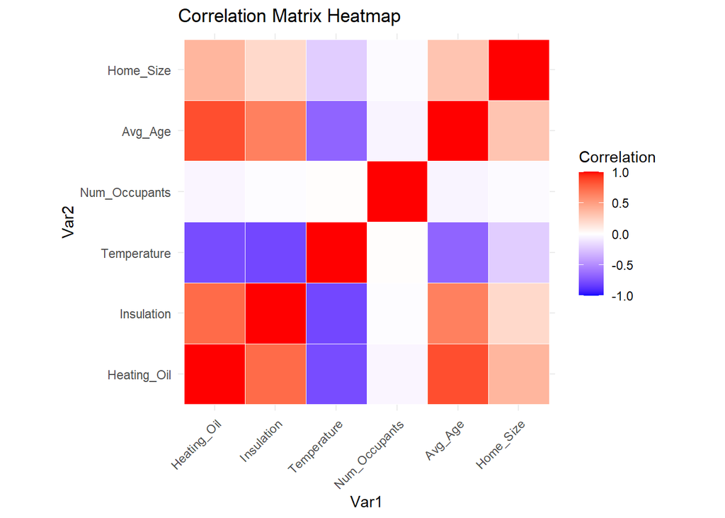

```r
# Memuat library
library(ggplot2)
library(reshape2)
# Membaca data
data <- read.csv("HeatingOil.csv")

# Menghitung korelasi
cor_matrix <- cor(data[, c("Heating_Oil", "Insulation", "Temperature", "Num_Occupants", "Avg_Age", "Home_Size")], use = "complete.obs")

# Mengubah matrix jadi format panjang
melted_cor <- melt(cor_matrix)

# Membuat heatmap
ggplot(data = melted_cor, aes(x = Var1, y = Var2, fill = value)) +
  geom_tile(color = "white") +
  scale_fill_gradient2(low = "blue", high = "red", mid = "white",
                       midpoint = 0, limit = c(-1, 1), space = "Lab",
                       name = "Correlation") +
  theme_minimal() +
  theme(axis.text.x = element_text(angle = 45, vjust = 1, hjust = 1)) +
  coord_fixed() +
  ggtitle("Correlation Matrix Heatmap")
```

**~Langkah 2: INTERPRETASI CORRELATION MATRIX**

Penjelasan dari Hasil Correlation Matrix, Variabel yang Memiliki Korelasi Signifikan dengan jumlah Konsumsi Heating_Oil:

- `Avg_Age(Positif):` Semakin tua penghuni rumah, makin tinggi penggunaan Heating_Oil. Kemungkinan karena orang yang lebih tua butuh suhu ruangan yang lebih hangat.
- `Temperature(Negatif):` Suhu makin rendah (lebih dingin) → penggunaan Heating_Oil makin tinggi. Ini masuk akal dan sangat kuat hubungannya.
- `Insulation(Positif):` Korelasi positif ini tidak biasa – bisa jadi insulasi yang dilaporkan bukan mencerminkan efisiensi tinggi, atau ada pengaruh lain.

**KESIMPULAN**

Konsumsi Heating_Oil sangat dipengaruhi oleh suhu, usia penghuni, dan tingkat insulasi rumah.

- Semakin dingin suhu dan semakin tua usia penghuni, konsumsi Heating_Oil meningkat.
- Hasil korelasi dengan Insulation tampak berlawanan dengan logika umum (karena biasanya rumah yang terinsulasi baik akan lebih hemat energi), Kemungkinan ada pengaruh lain.

**~Langkah 3: SCATTER PLOT 1**

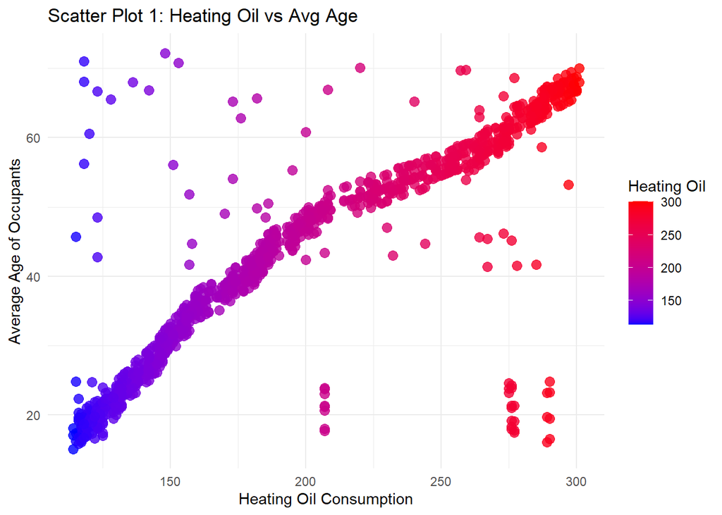

```r
# Muat library
library(ggplot2)

# Baca data
data <- read.csv("HeatingOil.csv")

# Buat scatter plot
ggplot(data, aes(x = Heating_Oil, y = Avg_Age, color = Heating_Oil)) +
  geom_point(size = 3, alpha = 0.8) +
  scale_color_gradient(low = "blue", high = "red") +
  labs(title = "Scatter Plot 1: Heating Oil vs Avg Age",
       x = "Heating Oil Consumption",
       y = "Average Age of Occupants",
       color = "Heating Oil") +
  theme_minimal()
```

**Penjelasan Hasil Scatter Plot 1**

Polanya: Jika kamu melihat bahwa titik-titik semakin naik ke atas (usia tinggi) cenderung berwarna merah (Heating Oil tinggi), itu artinya:

- Penghuni yang lebih tua cenderung menggunakan lebih banyak Heating Oil.
- Sebaliknya, jika warna merah banyak di bagian bawah grafik (usia muda), berarti pengguna muda yang konsumsi lebih banyak, tetapi berdasarkan korelasi sebelumnya (+0.85), kemungkinan besar pola yang terlihat adalah:**Semakin tua usia penghuni, semakin tinggi konsumsi Heating Oil.**

**~Langkah 4: SCATTER PLOT 2**

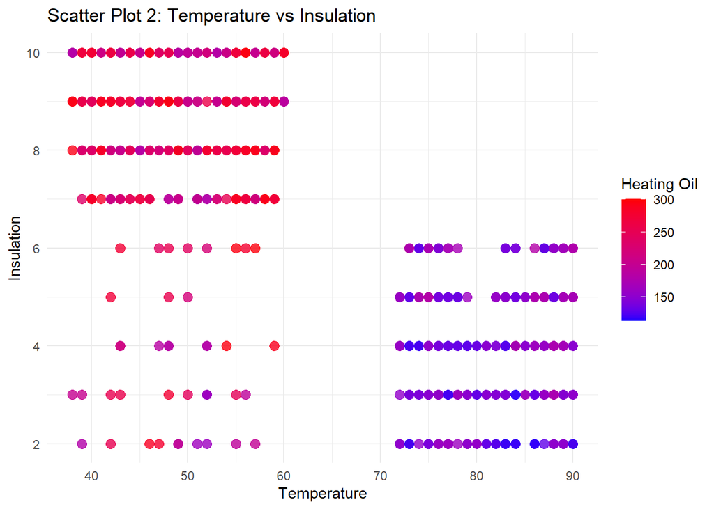

```r
# Muat library
library(ggplot2)

# Baca data
data <- read.csv("HeatingOil.csv")

# Buat scatter plot
ggplot(data, aes(x = Temperature, y = Insulation, color = Heating_Oil)) +
  geom_point(size = 3, alpha = 0.8) +
  scale_color_gradient(low = "blue", high = "red") +
  labs(title = "Scatter Plot 2: Temperature vs Insulation",
       x = "Temperature",
       y = "Insulation",
       color = "Heating Oil") +
  theme_minimal()
```

**Penjelasan Hasil Scatter Plot 2**

Berdasarkan scatter plot ini, kamu akan melihat hubungan antara suhu dan insulasi terhadap konsumsi minyak pemanas:

- Jika titik-titik di suhu rendah dan insulasi rendah → berwarna merah, maka: Konsumsi Heating Oil tinggi saat suhu dingin dan rumah kurang terinsulasi (logis).
- Jika insulasi tinggi justru banyak titik merah, maka: Ada kemungkinan rumah dengan insulasi tinggi tetap boros Heating Oil, bisa karena rumah besar, penghuni lebih tua, atau ada variabel lain.

**~Langkah 5: REKOMENDASI STRATEGI PEMASARAN UNTUK SARAH**

Berdasarkan hasil analisis korelasi dan dua scatter plot (Heating_Oil vs Avg_Age, dan Temperature vs Insulation), rekomendasi strategi pemasaran yang dapat diberikan kepada Sarah untuk meningkatkan efektivitas promosi produk Heating Oil adalah:

- Menargetkan pemasaran kepada penghuni rumah yang lebih tua, seperti Perumahan Pensiunan, Kompleks Warga Senior, Dan Lain-lain (Lakukan pendekatan yang menekankan pada kenyamanan dan kehangatan rumah, karena penghuni lansia cenderung lebih sensitif terhadap suhu dingin).
- Pemasaran ke Wilayah dengan suhu rendah/dingin atau promosi saat menjelang musim dingin.
- Evaluasi Rumah dengan Insulasi Tinggi tapi Tetap Boros, bisa jadi rumah-rumah ini besar, atau penghuni tetap menggunakan pemanas berlebih.

**SOAL NO 2:**  
Kini sarah dipromosikan menjadi VP Marketing. Ia bertanggung jawab atas ratusan marketer yang tersebar di berbagai wilayah. Salah satu tantangan yang dihadapinya adalah Data `HeatingOil.csv` bersifat rahasia dan hanya dapat diakses oleh Sarah (VP). Para marketer tidak boleh langsung melihat dataset tersebut, namun tetap diminta untuk memperkirakan kebutuhan minyak calon pelanggan baru.

Sarah ingin masing-masing marketer membuat proses yang dapat mengestimasi kebutuhan konsumsi minyak dari client yang mereka approach, dengan menggunakan model yang sebelumnya dihasilkan oleh Sarah, meskipun tanpa mengakses dataset `(HeatingOil.csv)`.

Data `HeatingOil-Marketing.csv` adalah data calon pelanggan yang berhasil di approach oleh salah satu marketingnya. Untuk mengatasi ini, Sarah ingin membuat model regresi prediktif, menyimpannya, dan mendistribusikan model tersebut ke semua marketer.

**~YANG HARUS DILAKUKAN SARAH ADALAH MEMBUAT PROSES UNTUK:**

- **Membaca dataset: HeatingOil.csv**

```r
# Load library
library(readr)

# Baca data asli
data_sarah <- read_csv("HeatingOil.csv", show_col_types = FALSE)

# Periksa nama kolom
colnames(data_sarah)
```

```
## [1] "Insulation"    "Temperature"   "Heating_Oil"   "Num_Occupants"
## [5] "Avg_Age"       "Home_Size"
```

- **Membuat model regresi untuk memprediksi konsumsi minyak (Heating_Oil).**

```r
# Buat model regresi
model <- lm(Heating_Oil ~ Insulation + Temperature + Num_Occupants + Avg_Age + Home_Size, data = data_sarah)

# Menampilkan ringkasan model
summary(model)
```

```
##
## Call:
## lm(formula = Heating_Oil ~ Insulation + Temperature + Num_Occupants +
##     Avg_Age + Home_Size, data = data_sarah)
##
## Residuals:
##      Min       1Q   Median       3Q      Max
## -103.558  -11.999    0.544   11.764  128.215
##
## Coefficients:
##                Estimate Std. Error t value Pr(>|t|)
## (Intercept)   135.48094    7.73091  17.525  < 2e-16 ***
## Insulation      3.32551    0.42044   7.910 5.78e-15 ***
## Temperature    -0.86993    0.07114 -12.228  < 2e-16 ***
## Num_Occupants  -0.26896    0.40689  -0.661    0.509
## Avg_Age         1.96582    0.06523  30.137  < 2e-16 ***
## Home_Size       3.17151    0.31088  10.202  < 2e-16 ***
## ---
## Signif. codes:  0 '***' 0.001 '**' 0.01 '*' 0.05 '.' 0.1 ' ' 1
##
## Residual standard error: 23.96 on 1212 degrees of freedom
## Multiple R-squared:  0.8193, Adjusted R-squared:  0.8186
## F-statistic:  1099 on 5 and 1212 DF,  p-value: < 2.2e-16
```

- **Menyimpan model agar dapat digunakan oleh marketer tanpa harus membagikan data HeatingOil.csv.**

```r
# Simpan model
saveRDS(model, file = "heating_oil_model.rds")
```

**~YANG HARUS DILAKUKAN MARKETER ADALAH MEMBUAT PROSES UNTUK:**

- **Membaca model yang sudah disimpan oleh Sarah**

```r
# Load library
library(readr)

# Load model yang dikirim oleh Sarah
model <- readRDS("heating_oil_model.rds")
```

- **Membaca data calon pelanggan baru: HeatingOil-Marketing.csv**

```r
# Baca data pelanggan baru
data_new <- read_csv("HeatingOil-Marketing.csv", show_col_types = FALSE)
```

- **Menerapkan model ke data calon pelanggan baru untuk memprediksi kebutuhan minyak pemanas rumah**

```r
# Prediksi konsumsi heating oil
prediksi <- predict(model, newdata = data_new)

# Tambahkan hasil ke data
data_new$Predicted_Heating_Oil <- prediksi

# Lihat hasil prediksi
head(data_new)
```

```
## # A tibble: 4 × 6
##   Insulation Temperature Num_Occupants Avg_Age Home_Size Predicted_Heating_Oil
##        <dbl>       <dbl>         <dbl>   <dbl>     <dbl>                 <dbl>
## 1          6          74             4    23.8         4                  149.
## 2         10          43             4    56.7         4                  254.
## 3          3          81             2    28           6                  149.
## 4          9          50             4    45.1         3                  219.
```

**Hasil & Keamanan Data**

- Data asli (HeatingOil.csv) tidak pernah dibagikan ke marketer
- Marketer hanya menggunakan model .rds untuk memprediksi
- Proses ini aman, efisien, dan bisa di-deploy ke banyak cabang

**- -Thank You- -**